# Exam 4 - Rotational Dynamics

**Date:** / /

**Class Number:** PHYS 1061 H002 **Instructor:** Michael Haas

**Name:**

Please read and follow all instructions carefully. Use the back of the sheet if necessary.

Indefinite evaluation of $\int (x+3x^2) dx = x^3 + \frac{x^2}{2} + C$

Score: / 42 + Bonus: / 6 = Total: / 42 || Final: % -> [A, B, C, D, F]

Problem #1 (3 points)

Two wheels, A and B, have the same shape and size, but wheel A has half the mass of wheel B. How do the moments of inertia (around the axis of symmetry) of the two wheels relate to each other?

1. $I_A = I_B$
2. $I_A = 2I_B$
3. $I_A = 4I_B$
4. $I_A = \frac{1}{2} I_B$
5. $I_A = \frac{1}{4} I_B$

Problem #2 (3 points)

Two wheels (same mass, same radius, same width) are rolled without slipping down an incline. Wheel A is a solid disk and wheel B is a hoop. Which wheel reaches the bottom first?

1. Wheel A
2. Wheel B
3. They reach the bottom at the same time
4. It depends on the incline angle

Problem #3 (3 points)

A solid sphere and a solid cube are raced down a slide. The sphere rolls without without slipping and the box slides without friction. Which object reaches the bottom first?

1. Sphere
2. Cube
3. They reach the bottom at the same time
4. It depends on the incline angle

Bonus #4 (3 points)

Will you vote tomorrow? (no wrong answer)

yes | no | maybe | I don't know | other | none of your business

Problem #5 (3 points)

Steve is pushing a door open (applying a force into the page at the doorknob), what direction is the torque applied relative to the axis of rotation (the hinges).

[figure not shown]

1. Into the page ($-z$)
2. Out of the page ($+z$)
3. Up ($+y$)
4. Down ($-y$)
5. Left ($-x$)
6. Right ($+x$)

Problem #6 (3 points)

A person is sitting on a spinning stool rotating at $10.0 \frac{\mathrm{rad}}{\mathrm{s}}$. They are holding weights close to their chest. The person then extends their arms outwards. What happens to the stool's angular velocity?

1. It increases
2. It decreases
3. It stays the same
4. It depends on the mass of the weights

Problem #7 (3 points)

The wrench in the figure has six forces of equal magnitude acting on it.

Question #1 ( 3 points

Rank these forces (A through F) on the basis of the magnitude (greatest to least) of the torque they apply to the wrench, measured about an axis centered on the bolt. If two are the same, list them alphabetically

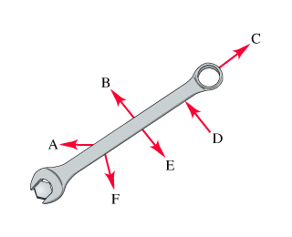

Problem #8 (12 points)

A DVD (disc) has a mass of $16.0 \mathrm{g}$ and a diameter of $12.0 \mathrm{cm}$. The player is spinning it at an angular speed of $9280. \mathrm{rpm}$ (one rotation is $2\pi$ radians) when it is turned off and slows to a stop in $2.50 \mathrm{s}$.

Question #1 ( 3 points

What is the moment of inertia of the DVD?

Question #2 ( 3 points

What is the magnitude and direction of the torque felt by the DVD?

Question #3 ( 3 points

What is the initial angular momentum of the DVD?

Question #4 ( 3 points

What is the linear (straight line) speed of two points on the DVD: a point at the edge of the DVD, and a point $2.00 \mathrm{cm}$ from the center?

Bonus #9 (3 points)

Evaluate the definite integral $\int_0^{2} (x+3x^2) dx$. (recall: integral means anti-derivative, or area under a curve)

Problem #10 (12 points)

A rubber ball (solid sphere) with a diameter of $0.314 \mathrm{m}$ is rolling without slipping with an initial linear speed $v=5.00 \frac{\mathrm{m}}{\mathrm{s}}$ from the top of a hill, $325. \mathrm{m}$ high, to the bottom.

Question #1 ( 3 points

Draw a diagram showing this situation. Include a before and after picture labeling all relevant quantities.

Question #2 ( 3 points

Derive an equation for the total kinetic energy in terms of $m$ and $v$.

Question #3 ( 3 points

When the ball reaches the bottom of the hill what will its linear speed be?

Question #4 ( 3 points

What will be the rotational speed of the ball at the bottom of the hill?